# Modeling and prediction for movies

### Load packages

```r
library(ggplot2)
library(dplyr)
library(statsr)
library(GGally)
library(DAAG)
library(devtools)
```

### Load data.

```r
load("~/R/Linear Regression and Modeling/Project/movies.Rdata")
```

## Part 1: Data

Since this wasn’t an experiment, causal connections cannot be made here. That is, data in this study was merely observed and as such only generalisations can be made.

## Part 2: Research question

**Q: Can we observe an association between the imdb rating of a movie and other variables such as the length of a movie and audience polls on Rotten tomatoes?**

All the registered members of IMDb can cast their votes/ratings for any movie. IMDb takes all the individual votes cast by the registered users and uses them to calculate a single rating. It is widely known that the weighted average method is used in this calculation and as such it could lead to manipulation of votes. Being able to predict the imdb rating based on historical data could be useful in checking this phenomenon.

## Part 3: Exploratory data analysis

First, we merge the best_pic_nom and best_pic_win variables and create a new one, best_pic. Just to de-congest the dataset.

```r
movies <- movies %>%
  mutate(best_pic = ifelse(best_pic_nom == "no" & best_pic_win == "no", "No BPEntry",
    ifelse(best_pic_nom == "yes" & best_pic_win == "no", "Lost BP",
           ifelse(best_pic_nom == "yes" & best_pic_win == "yes", "Won BP",
                  NA))))
```

**Categorical:**

- title_type (candidate explanantory var)
- genre (ditto)
- mpaa_rating (ditto)
- critics rating (ditto)
- audience_rating (ditto)
- best_pic (ditto)

**Numerical:**

- imdb_rating (response var)
- runtime (candidate explanantory var)
- imdb_num_votes (ditto)
- critics_score (ditto)
- audience_score (ditto)

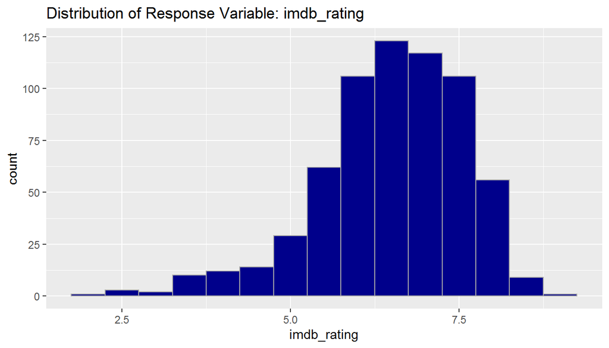

```r
ggplot(data = movies, aes(x = imdb_rating)) +
  geom_histogram(binwidth = 0.5, color='darkgray', fill  = 'darkblue') +
  labs(title = "Distribution of Response Variable: imdb_rating" )
```

```r
summary(movies$imdb_rating)
```

```
##    Min. 1st Qu.  Median    Mean 3rd Qu.    Max.
##   1.900   5.900   6.600   6.493   7.300   9.000
```

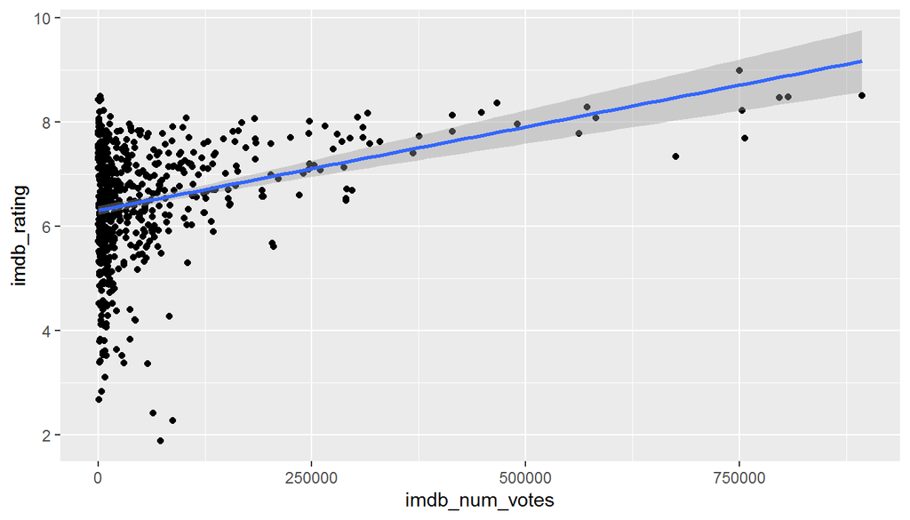

```r
ggplot(data = movies, aes(x = imdb_num_votes, y = imdb_rating)) +
  geom_jitter() +
  geom_smooth(method = "lm")
```

```r
# type your code for the Exercise here, and Knit
imdb_rating_votes <- lm(imdb_rating ~ imdb_num_votes, data = movies)
summary(imdb_rating_votes)
```

```
##
## Call:
## lm(formula = imdb_rating ~ imdb_num_votes, data = movies)
##
## Residuals:
##     Min      1Q  Median      3Q     Max
## -4.6433 -0.5205  0.0798  0.7004  2.1837
##
## Coefficients:
##                 Estimate Std. Error t value Pr(>|t|)
## (Intercept)    6.309e+00  4.513e-02 139.789   <2e-16 ***
## imdb_num_votes 3.204e-06  3.583e-07   8.941   <2e-16 ***
## ---
## Signif. codes:  0 '***' 0.001 '**' 0.01 '*' 0.05 '.' 0.1 ' ' 1
##
## Residual standard error: 1.024 on 649 degrees of freedom
## Multiple R-squared:  0.1097, Adjusted R-squared:  0.1083
## F-statistic: 79.94 on 1 and 649 DF,  p-value: < 2.2e-16
```

```r
row_to_keep = which(!(movies$imdb_num_votes > 250000))
movies_n = movies[row_to_keep,]
```

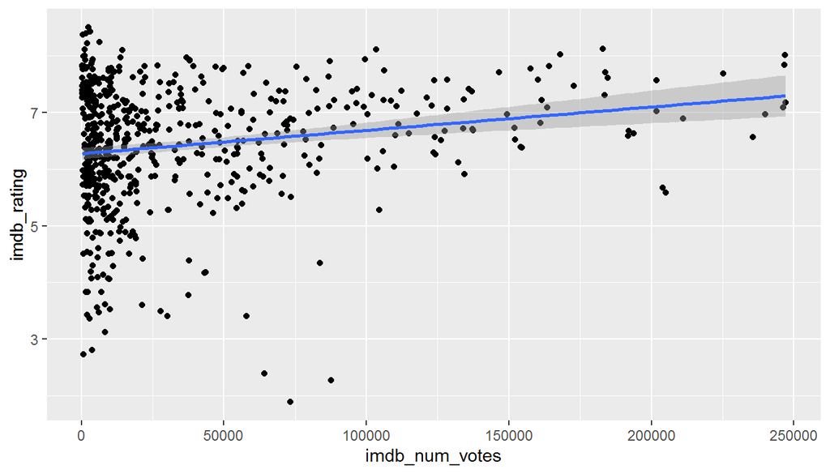

```r
ggplot(data = movies_n, aes(x = imdb_num_votes, y = imdb_rating)) +
  geom_jitter() +
  geom_smooth(method = "lm")
```

```r
labs(title = "Scatter Plot of imdb_rating Vs imdb_num_votes" )
```

```
## $title
## [1] "Scatter Plot of imdb_rating Vs imdb_num_votes"
##
## attr(,"class")
## [1] "labels"
```

```r
# type your code for the Exercise here, and Knit
imdb_rating_votes <- lm(imdb_rating ~ imdb_num_votes, data = movies_n)
summary(imdb_rating_votes)
```

```
##
## Call:
## lm(formula = imdb_rating ~ imdb_num_votes, data = movies_n)
##
## Residuals:
##     Min      1Q  Median      3Q     Max
## -4.6764 -0.5136  0.0767  0.7284  2.2157
##
## Coefficients:
##                 Estimate Std. Error t value Pr(>|t|)
## (Intercept)    6.275e+00  5.208e-02 120.479  < 2e-16 ***
## imdb_num_votes 4.122e-06  8.561e-07   4.815 1.86e-06 ***
## ---
## Signif. codes:  0 '***' 0.001 '**' 0.01 '*' 0.05 '.' 0.1 ' ' 1
##
## Residual standard error: 1.045 on 614 degrees of freedom
## Multiple R-squared:  0.03638,    Adjusted R-squared:  0.03481
## F-statistic: 23.18 on 1 and 614 DF,  p-value: 1.857e-06
```

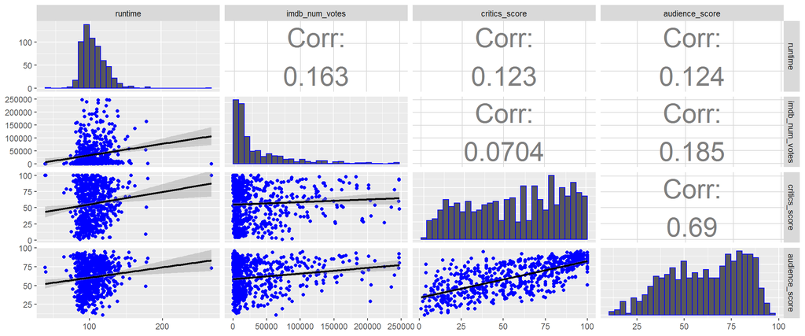

```r
cand_cols <- c(4,14,16,18)
ggpairs(movies_n,
        columns = cand_cols,
        upper = list(continuous = wrap("cor", size = 10)),
        diag = list(continuous = wrap("barDiag", colour = "blue")),
        lower = list(continuous = wrap("smooth", colour = 'blue')))
```

Since we can observe the lack of collinearity among the variables except for that which exists between audience score and critics score, we can conclude that all the variables can be included in the initial full model- the only caveat being that either the audience score or the critics score be picked but not both. Also, looking at the above pairwise plots, the data for imdb_num_votes is strongly right skewed. This strong skew can be taken care of by log transforming the imdb_num_votes variable for the number of observations left.

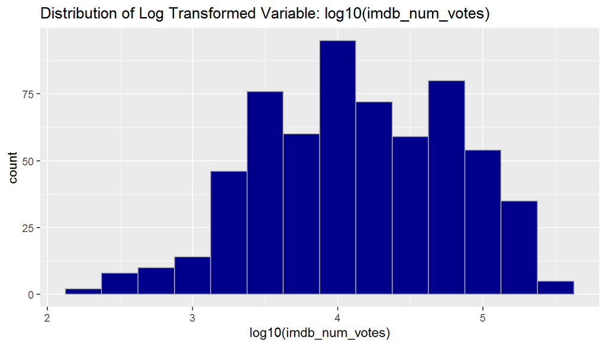

```r
ggplot(data = movies_n, aes (x = log10(imdb_num_votes))) +
  geom_histogram(binwidth = 0.25, color='darkgray', fill  = 'darkblue') +
  labs(title = "Distribution of Log Transformed Variable: log10(imdb_num_votes)" )
```

This looks much better, nearly normal.

Lets consider the runtime as well. Since this is also a numeric variable.

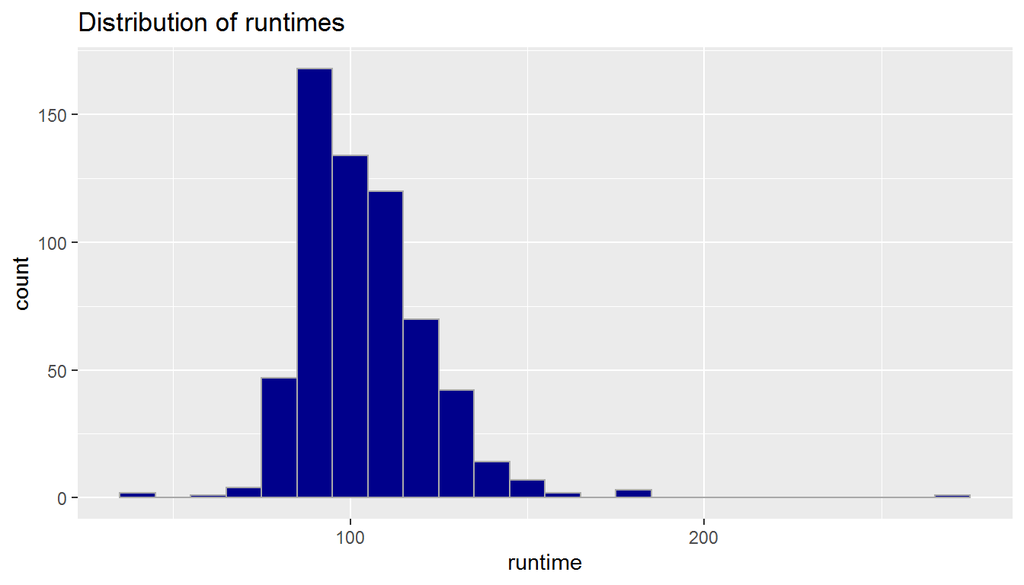

```r
ggplot(data = movies_n, aes (x = runtime)) +
  geom_histogram(binwidth = 10, color='darkgray', fill  = 'darkblue') +
  labs(title = "Distribution of runtimes")
```

```r
summary(movies_n$runtime)
```

```
##    Min. 1st Qu.  Median    Mean 3rd Qu.    Max.    NA's
##    39.0    92.0   101.0   104.5   114.0   267.0       1
```

In this case, since the runtimes have a size n > 30, its slight right skewness will not be a problem.

Now lets ascertain whether there is a linear relationship between the variables we’ve looked at and the response variable.

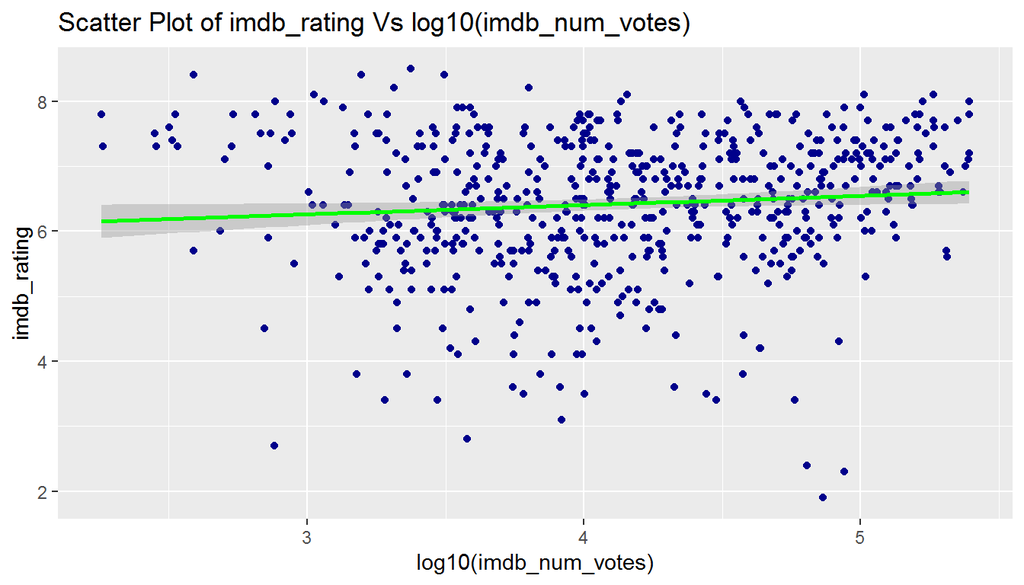

```r
ggplot(data = movies_n, aes (x = log10(imdb_num_votes), y = imdb_rating)) +
  geom_point(color = 'darkblue') +
  geom_smooth(method = 'lm', formula = y~x, color = 'green') +
  labs(title = "Scatter Plot of imdb_rating Vs log10(imdb_num_votes)" )
```

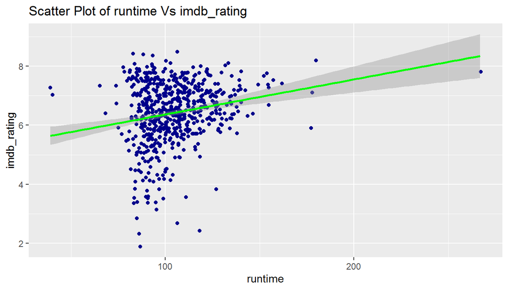

```r
ggplot(data = movies_n, aes (x = runtime, y = imdb_rating)) +
  geom_jitter(color = 'darkblue') +
  geom_smooth(method = 'lm', formula = y~x, color = 'green') +
  labs(title = "Scatter Plot of runtime Vs imdb_rating" )
```

There looks to be a linear relationship, albeit stronger in the second instance with the runtime variable.

## Part 4: Modeling

```r
initial_model = lm(imdb_rating ~ runtime +
                  log10(imdb_num_votes) ,
                  data = movies_n)
summary(initial_model)
```

```
##
## Call:
## lm(formula = imdb_rating ~ runtime + log10(imdb_num_votes), data = movies_n)
##
## Residuals:
##     Min      1Q  Median      3Q     Max
## -4.3896 -0.5561  0.0465  0.7200  2.3063
##
## Coefficients:
##                       Estimate Std. Error t value Pr(>|t|)
## (Intercept)           4.870183   0.330152  14.751  < 2e-16 ***
## runtime               0.011258   0.002354   4.783 2.16e-06 ***
## log10(imdb_num_votes) 0.090456   0.064558   1.401    0.162
## ---
## Signif. codes:  0 '***' 0.001 '**' 0.01 '*' 0.05 '.' 0.1 ' ' 1
##
## Residual standard error: 1.041 on 612 degrees of freedom
##   (1 observation deleted due to missingness)
## Multiple R-squared:  0.04426,    Adjusted R-squared:  0.04114
## F-statistic: 14.17 on 2 and 612 DF,  p-value: 9.641e-07
```

We have an adjusted R-squared of 0.04114 Next, we add our newly created variable, best_pic.

```r
updated_model1 = lm(imdb_rating ~ runtime +
                  log10(imdb_num_votes) +
                    best_pic,
                  data = movies_n)
summary(updated_model1)
```

```
##
## Call:
## lm(formula = imdb_rating ~ runtime + log10(imdb_num_votes) +
##     best_pic, data = movies_n)
##
## Residuals:
##     Min      1Q  Median      3Q     Max
## -4.3702 -0.5439  0.0400  0.6939  2.2833
##
## Coefficients:
##                        Estimate Std. Error t value Pr(>|t|)
## (Intercept)            5.860117   0.495792  11.820  < 2e-16 ***
## runtime                0.010288   0.002364   4.351 1.59e-05 ***
## log10(imdb_num_votes)  0.067362   0.064670   1.042   0.2980
## best_picNo BPEntry    -0.812607   0.319919  -2.540   0.0113 *
## best_picWon BP         0.217062   0.675122   0.322   0.7479
## ---
## Signif. codes:  0 '***' 0.001 '**' 0.01 '*' 0.05 '.' 0.1 ' ' 1
##
## Residual standard error: 1.035 on 610 degrees of freedom
##   (1 observation deleted due to missingness)
## Multiple R-squared:  0.05839,    Adjusted R-squared:  0.05222
## F-statistic: 9.457 on 4 and 610 DF,  p-value: 2.016e-07
```

It has increased to an adjusted R-squared of 0.05222.

```r
updated_model2 = lm(imdb_rating ~ runtime +
                  log10(imdb_num_votes) +
                    best_pic+
                     genre,
                  data = movies_n)
summary(updated_model2)
```

```
##
## Call:
## lm(formula = imdb_rating ~ runtime + log10(imdb_num_votes) +
##     best_pic + genre, data = movies_n)
##
## Residuals:
##     Min      1Q  Median      3Q     Max
## -4.0387 -0.4046  0.0696  0.5219  2.2493
##
## Coefficients:
##                                 Estimate Std. Error t value Pr(>|t|)
## (Intercept)                     3.794995   0.456687   8.310 6.41e-16 ***
## runtime                         0.005653   0.002083   2.714  0.00685 **
## log10(imdb_num_votes)           0.466615   0.059666   7.820 2.38e-14 ***
## best_picNo BPEntry             -0.601782   0.266460  -2.258  0.02428 *
## best_picWon BP                  0.264471   0.560656   0.472  0.63730
## genreAnimation                  0.112492   0.308156   0.365  0.71520
## genreArt House & International  1.082409   0.258007   4.195 3.14e-05 ***
## genreComedy                    -0.016224   0.145674  -0.111  0.91136
## genreDocumentary                2.376941   0.177966  13.356  < 2e-16 ***
## genreDrama                      0.812626   0.124128   6.547 1.26e-10 ***
## genreHorror                     0.110777   0.211908   0.523  0.60134
## genreMusical & Performing Arts  1.653632   0.274983   6.014 3.15e-09 ***
## genreMystery & Suspense         0.521300   0.161958   3.219  0.00136 **
## genreOther                      0.616205   0.264319   2.331  0.02007 *
## genreScience Fiction & Fantasy -0.331995   0.344209  -0.965  0.33518
## ---
## Signif. codes:  0 '***' 0.001 '**' 0.01 '*' 0.05 '.' 0.1 ' ' 1
##
## Residual standard error: 0.8581 on 600 degrees of freedom
##   (1 observation deleted due to missingness)
## Multiple R-squared:  0.3636, Adjusted R-squared:  0.3487
## F-statistic: 24.49 on 14 and 600 DF,  p-value: < 2.2e-16
```

On adding the genre explanatory variable, we see a vast improvement in our model, with an adjusted R-squared value of 0.3487. Next, we add the title type..

```r
updated_model3 = lm(imdb_rating ~ runtime +
                       title_type+
                  log10(imdb_num_votes) +
                    best_pic+
                     genre,
                  data = movies_n)
summary(updated_model3)
```

```
##
## Call:
## lm(formula = imdb_rating ~ runtime + title_type + log10(imdb_num_votes) +
##     best_pic + genre, data = movies_n)
##
## Residuals:
##     Min      1Q  Median      3Q     Max
## -4.0332 -0.3916  0.0439  0.5227  2.2317
##
## Coefficients:
##                                 Estimate Std. Error t value Pr(>|t|)
## (Intercept)                     4.915278   0.529234   9.288  < 2e-16 ***
## runtime                         0.005438   0.002060   2.640 0.008502 **
## title_typeFeature Film         -1.265139   0.314313  -4.025 6.43e-05 ***
## title_typeTV Movie             -1.438224   0.494832  -2.906 0.003790 **
## log10(imdb_num_votes)           0.500289   0.059796   8.367 4.20e-16 ***
## best_picNo BPEntry             -0.586680   0.263340  -2.228 0.026262 *
## best_picWon BP                  0.260122   0.554037   0.470 0.638881
## genreAnimation                  0.109344   0.304514   0.359 0.719664
## genreArt House & International  1.107001   0.255061   4.340 1.67e-05 ***
## genreComedy                    -0.037109   0.144047  -0.258 0.796791
## genreDocumentary                1.225901   0.335162   3.658 0.000277 ***
## genreDrama                      0.828296   0.122781   6.746 3.59e-11 ***
## genreHorror                     0.120602   0.209431   0.576 0.564928
## genreMusical & Performing Arts  1.255477   0.289089   4.343 1.65e-05 ***
## genreMystery & Suspense         0.528606   0.160055   3.303 0.001015 **
## genreOther                      0.648126   0.262682   2.467 0.013891 *
## genreScience Fiction & Fantasy -0.318652   0.340169  -0.937 0.349268
## ---
## Signif. codes:  0 '***' 0.001 '**' 0.01 '*' 0.05 '.' 0.1 ' ' 1
##
## Residual standard error: 0.8479 on 598 degrees of freedom
##   (1 observation deleted due to missingness)
## Multiple R-squared:  0.3806, Adjusted R-squared:  0.3641
## F-statistic: 22.97 on 16 and 598 DF,  p-value: < 2.2e-16
```

Here, a slight improvement but very significant. Next, we add the top200_box variable to the explanatory variable set.

```r
updated_model4 = lm(imdb_rating ~ runtime +
                       title_type+
                  log10(imdb_num_votes) +
                    best_pic+
                     genre +
                    top200_box,
                  data = movies_n)
summary(updated_model4)
```

```
##
## Call:
## lm(formula = imdb_rating ~ runtime + title_type + log10(imdb_num_votes) +
##     best_pic + genre + top200_box, data = movies_n)
##
## Residuals:
##     Min      1Q  Median      3Q     Max
## -4.0273 -0.3956  0.0468  0.5283  2.2361
##
## Coefficients:
##                                 Estimate Std. Error t value Pr(>|t|)
## (Intercept)                     4.891829   0.529269   9.243  < 2e-16 ***
## runtime                         0.005433   0.002059   2.639 0.008530 **
## title_typeFeature Film         -1.257982   0.314196  -4.004 7.02e-05 ***
## title_typeTV Movie             -1.427635   0.494637  -2.886 0.004040 **
## log10(imdb_num_votes)           0.491157   0.060189   8.160 1.99e-15 ***
## best_picNo BPEntry             -0.559558   0.264052  -2.119 0.034492 *
## best_picWon BP                  0.297511   0.554512   0.537 0.591794
## genreAnimation                  0.140083   0.305298   0.459 0.646516
## genreArt House & International  1.131163   0.255623   4.425 1.15e-05 ***
## genreComedy                    -0.008937   0.145644  -0.061 0.951090
## genreDocumentary                1.252349   0.335621   3.731 0.000209 ***
## genreDrama                      0.853058   0.124232   6.867 1.65e-11 ***
## genreHorror                     0.148134   0.210422   0.704 0.481715
## genreMusical & Performing Arts  1.283041   0.289737   4.428 1.13e-05 ***
## genreMystery & Suspense         0.558402   0.161655   3.454 0.000591 ***
## genreOther                      0.644998   0.262554   2.457 0.014308 *
## genreScience Fiction & Fantasy -0.292163   0.340618  -0.858 0.391377
## top200_boxyes                   0.376829   0.294478   1.280 0.201166
## ---
## Signif. codes:  0 '***' 0.001 '**' 0.01 '*' 0.05 '.' 0.1 ' ' 1
##
## Residual standard error: 0.8475 on 597 degrees of freedom
##   (1 observation deleted due to missingness)
## Multiple R-squared:  0.3823, Adjusted R-squared:  0.3647
## F-statistic: 21.74 on 17 and 597 DF,  p-value: < 2.2e-16
```

Here, we realise that the top200_box isn’t such a siginificant contributor to the response variable and as such we can return to the updated_model3 and include some other variable - mpaa_rating and audience score on Rotten Tomatoes, audience_score.

```r
updated_model5 = lm(imdb_rating ~ runtime +
                       title_type+
                  log10(imdb_num_votes) +
                    best_pic+
                     genre+
                    mpaa_rating,
                  data = movies_n)
summary(updated_model5)
```

```
##
## Call:
## lm(formula = imdb_rating ~ runtime + title_type + log10(imdb_num_votes) +
##     best_pic + genre + mpaa_rating, data = movies_n)
##
## Residuals:
##     Min      1Q  Median      3Q     Max
## -3.8041 -0.3709  0.0550  0.4840  1.9762
##
## Coefficients:
##                                 Estimate Std. Error t value Pr(>|t|)
## (Intercept)                     5.157479   0.550311   9.372  < 2e-16 ***
## runtime                         0.006387   0.002034   3.141 0.001770 **
## title_typeFeature Film         -1.145751   0.309148  -3.706 0.000230 ***
## title_typeTV Movie             -1.475087   0.483355  -3.052 0.002377 **
## log10(imdb_num_votes)           0.551567   0.059403   9.285  < 2e-16 ***
## best_picNo BPEntry             -0.584401   0.257334  -2.271 0.023506 *
## best_picWon BP                  0.095863   0.541940   0.177 0.859657
## genreAnimation                 -0.365204   0.323524  -1.129 0.259426
## genreArt House & International  1.031554   0.254230   4.058 5.62e-05 ***
## genreComedy                     0.071139   0.142176   0.500 0.617010
## genreDocumentary                1.136682   0.330885   3.435 0.000633 ***
## genreDrama                      0.858050   0.122928   6.980 7.92e-12 ***
## genreHorror                     0.079910   0.209239   0.382 0.702666
## genreMusical & Performing Arts  1.242024   0.283215   4.385 1.37e-05 ***
## genreMystery & Suspense         0.539797   0.160198   3.370 0.000802 ***
## genreOther                      0.655610   0.256955   2.551 0.010977 *
## genreScience Fiction & Fantasy -0.371434   0.332091  -1.118 0.263820
## mpaa_ratingNC-17               -0.257248   0.626957  -0.410 0.681725
## mpaa_ratingPG                  -0.608953   0.227846  -2.673 0.007732 **
## mpaa_ratingPG-13               -1.033159   0.233021  -4.434 1.10e-05 ***
## mpaa_ratingR                   -0.659197   0.225754  -2.920 0.003634 **
## mpaa_ratingUnrated             -0.297153   0.260923  -1.139 0.255224
## ---
## Signif. codes:  0 '***' 0.001 '**' 0.01 '*' 0.05 '.' 0.1 ' ' 1
##
## Residual standard error: 0.827 on 593 degrees of freedom
##   (1 observation deleted due to missingness)
## Multiple R-squared:  0.4158, Adjusted R-squared:  0.3951
## F-statistic:  20.1 on 21 and 593 DF,  p-value: < 2.2e-16
```

```r
updated_model6 = lm(imdb_rating ~ runtime +
                       title_type+
                  log10(imdb_num_votes) +
                    best_pic+
                     genre+
                    mpaa_rating+
                    audience_score,
                  data = movies_n)
summary(updated_model6)
```

```
##
## Call:
## lm(formula = imdb_rating ~ runtime + title_type + log10(imdb_num_votes) +
##     best_pic + genre + mpaa_rating + audience_score, data = movies_n)
##
## Residuals:
##      Min       1Q   Median       3Q      Max
## -2.74301 -0.17667  0.06581  0.28121  1.09825
##
## Coefficients:
##                                  Estimate Std. Error t value Pr(>|t|)
## (Intercept)                     3.2607214  0.3440336   9.478  < 2e-16 ***
## runtime                         0.0046214  0.0012527   3.689 0.000246 ***
## title_typeFeature Film         -0.4147744  0.1916648  -2.164 0.030859 *
## title_typeTV Movie             -0.5696993  0.2988349  -1.906 0.057082 .
## log10(imdb_num_votes)           0.1445887  0.0388089   3.726 0.000213 ***
## best_picNo BPEntry              0.0492692  0.1596420   0.309 0.757717
## best_picWon BP                  0.1656976  0.3334802   0.497 0.619462
## genreAnimation                 -0.4649390  0.1991002  -2.335 0.019866 *
## genreArt House & International  0.3553194  0.1579291   2.250 0.024824 *
## genreComedy                    -0.0822401  0.0876232  -0.939 0.348337
## genreDocumentary                0.3142751  0.2053020   1.531 0.126354
## genreDrama                      0.2699797  0.0779526   3.463 0.000572 ***
## genreHorror                     0.2233479  0.1288332   1.734 0.083506 .
## genreMusical & Performing Arts  0.1988062  0.1774475   1.120 0.263012
## genreMystery & Suspense         0.4340559  0.0986329   4.401 1.28e-05 ***
## genreOther                      0.1016223  0.1591056   0.639 0.523259
## genreScience Fiction & Fantasy -0.1123482  0.2045147  -0.549 0.582979
## mpaa_ratingNC-17               -0.0007981  0.3858736  -0.002 0.998350
## mpaa_ratingPG                  -0.2481552  0.1406764  -1.764 0.078245 .
## mpaa_ratingPG-13               -0.3116396  0.1452366  -2.146 0.032300 *
## mpaa_ratingR                   -0.2178569  0.1396315  -1.560 0.119241
## mpaa_ratingUnrated             -0.1751999  0.1606015  -1.091 0.275761
## audience_score                  0.0400075  0.0012818  31.212  < 2e-16 ***
## ---
## Signif. codes:  0 '***' 0.001 '**' 0.01 '*' 0.05 '.' 0.1 ' ' 1
##
## Residual standard error: 0.5089 on 592 degrees of freedom
##   (1 observation deleted due to missingness)
## Multiple R-squared:  0.7792, Adjusted R-squared:  0.771
## F-statistic: 94.95 on 22 and 592 DF,  p-value: < 2.2e-16
```

Great! So as can be seen, the greatest Adjusted R-squared has been arrived at - 0.771. In conclusion, we see that the model without the inclusion of the top200_box variable seems just fine in predicting the imdb_rating.

Now, let’s run diagnostics on our model just to be sure we’re good to go. The following would be the criteria: 1. Linear relationships between (numerical) x and y 2. Nearly normal residuals with mean 0 3. Constant variability of residuals 4. Independent residuals

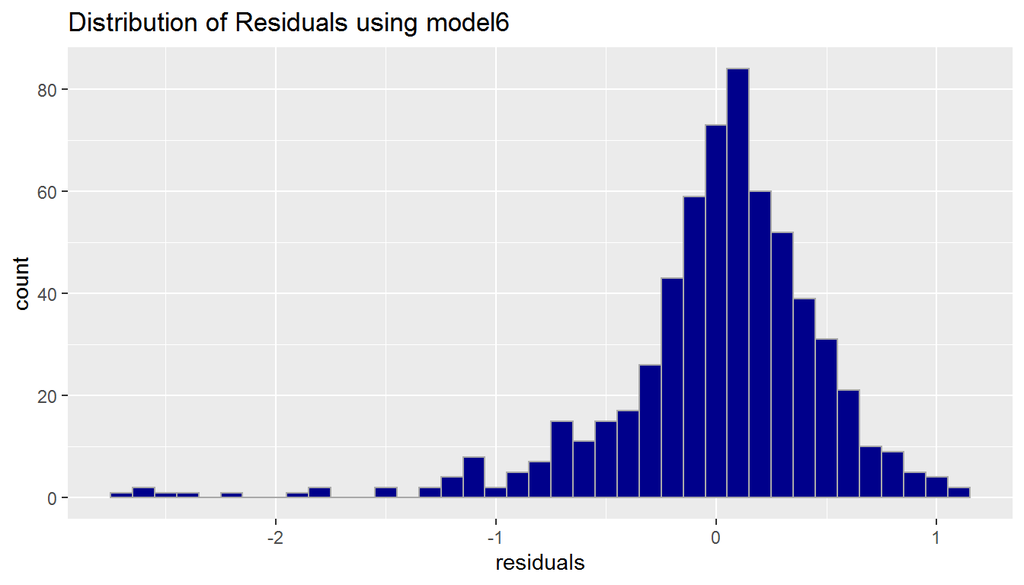

```r
ggplot(data = updated_model6, aes(x = updated_model6$residuals)) +
  geom_histogram(color = 'darkgray', fill = 'darkblue', binwidth = 0.1)  +
  labs(x = "residuals", title = "Distribution of Residuals using model6" )
```

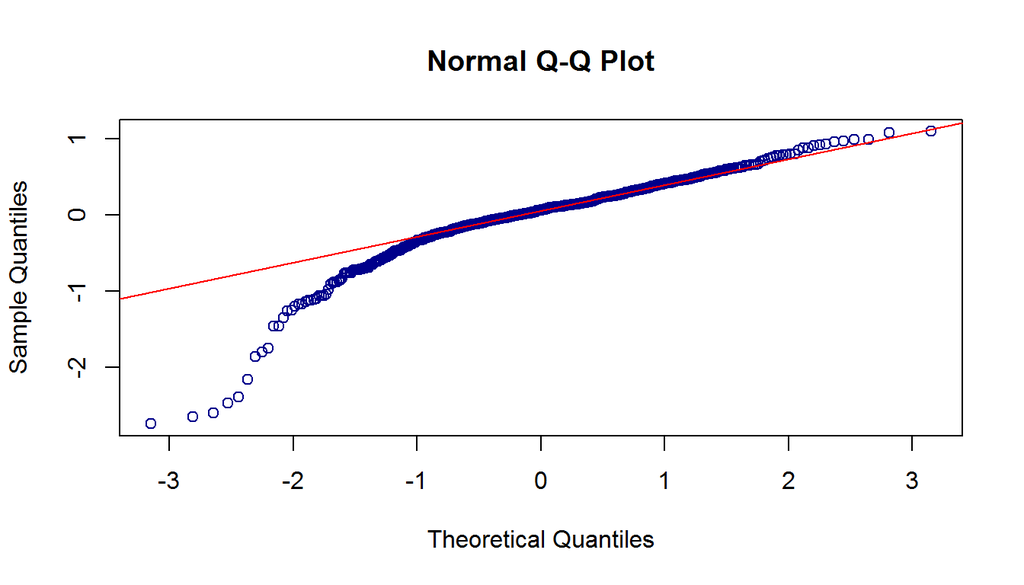

```r
qqnorm(updated_model6$residuals, col = 'darkblue')
qqline(updated_model6$residuals, col = 'red')
```

```r
summary(updated_model6$residuals)
```

```
##     Min.  1st Qu.   Median     Mean  3rd Qu.     Max.
## -2.74301 -0.17667  0.06581  0.00000  0.28121  1.09825
```

From the summary statistics the mean of the residuals can be seen to equal zero. However, the histogram shows that the residuals are left skewed. A proportion of outliers is the cause of this. The Q-Q plot also indicates a nearly normal distribution, with some deviation from normality occurring on the left hand side, indicating again that the data is left skewed.

For condition 3, let’s plot the residuals against the predictions.

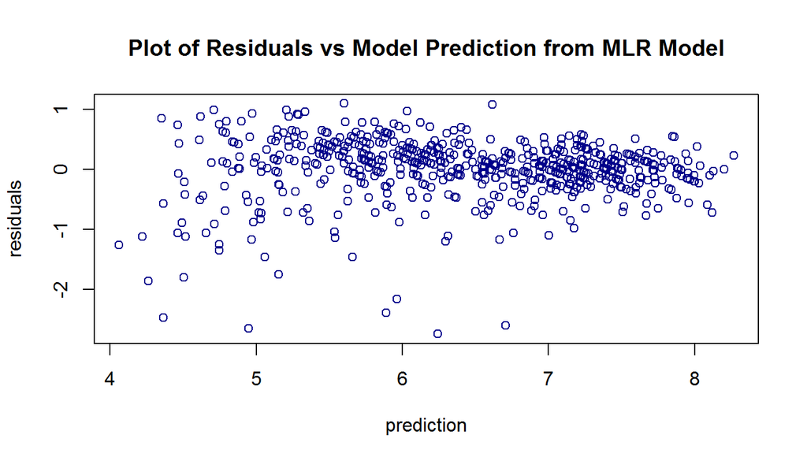

```r
plot(updated_model6$residuals ~ updated_model6$fitted,
     main = 'Plot of Residuals vs Model Prediction from MLR Model',
     xlab = 'prediction',
     ylab = 'residuals',
     col = 'darkblue')
```

The plot show that the variability of residuals is not constant. Thus, the SE, CI and hypothesis tests could be affected.. Later on, I’ll look up how to fix inconsistent residuals because it could affect the accuracy of my model.

For condition 4, lets plot the residuals as they are observed in the data.

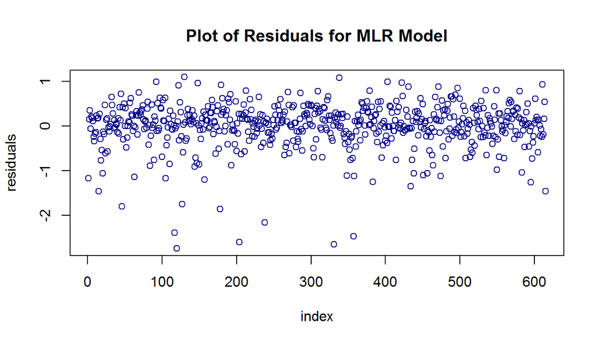

```r
plot(updated_model6$residuals,
     main = 'Plot of Residuals for MLR Model',
     xlab = 'index',
     ylab = 'residuals',
     col = 'darkblue')
```

From the plot, the residuals are randomly distributed. They are therefore independent.

## Part 5: Prediction

We chose Deadpool (2016) as our trial movie.

```r
Deadpool = data.frame(runtime = 108,
                      title_type = 'Feature Film',
                      genre = 'Action & Adventure',
                     mpaa_rating = 'R',
                     imdb_num_votes = 869288,
                     best_pic = 'No BPEntry',
                     audience_score = 90,
                     stringsAsFactors=FALSE)
predict(updated_model6,
        Deadpool,
        interval = "prediction",
        level = 0.95)
```

```
##        fit      lwr      upr
## 1 7.635883 6.619708 8.652059
```